[ 스타벅스 & 이디야 입지환경 분석 2 ]

# 이디야 & 컴포지 비교

### 이디야 매장이 전략적으로 스타벅스 매장 인근에 입점한다는 설에 대한 좀 더 직접적인 분석을 하고자, 저가형 커피 브랜드인 컴포지 매장과의 근접 거리 등을 비교해 본다. ( 이디야가 최근에는 저가형 브랜드보다 더 높은 상품 가격을 형성하고 있음.)

```python
import os
import geopandas as gpd
import osmnx as ox
import networkx as nx
from shapely.geometry import Point

import numpy as np
import pandas as pd
from tqdm import tqdm
import matplotlib.pyplot as plt
import seaborn as sns

from pyproj import Transformer
from matplotlib.colors import TwoSlopeNorm

from IPython.display import clear_output
from IPython.display import Image

import pickle

import warnings
warnings.filterwarnings(action='ignore')
import sys
#sys.stdout = open(os.devnull, 'w')
sys.stderr = open(os.devnull, 'w')
root = os.getcwd()

pd.options.display.float_format = '{:.0f}'.format # 소수점 표시 안되게
#pd.options.display.float_format = None   # 소수점을 모두 표시

plt.rcParams['font.family'] = 'Malgun Gothic'
```

지난 분석에서 활용한 데이터 + 컴포즈 공간 데이터 불러오기

```python
with open('G_utm.pkl', 'rb') as file:
    G_utm = pickle.load(file)

with open('subway.pkl', 'rb') as file:
    subway = pickle.load(file)
sub_crds = [[list(subway.geometry[i].coords)[0][0], list(subway.geometry[i].coords)[0][1]] for i in range(len(subway))]
sub_crds_arr = np.array(sub_crds)

with open('starbucks.pkl', 'rb') as file:
    starbucks = pickle.load(file)
with open('ediya.pkl', 'rb') as file:
    ediya = pickle.load(file)
with open('compo.pkl', 'rb') as file:
    compo = pickle.load(file)

with open('starbucks_geo.pkl', 'rb') as file:
    starbucks_geo = pickle.load(file)
with open('ediya_geo.pkl', 'rb') as file:
    ediya_geo = pickle.load(file)
with open('compo_geo.pkl', 'rb') as file:
    compo_geo = pickle.load(file)

with open('nearest_sb.pkl', 'rb') as file:
    nearest_sb = pickle.load(file)
with open('nearest_id.pkl', 'rb') as file:
    nearest_id = pickle.load(file)
with open('nearest_cp.pkl', 'rb') as file:
    nearest_cp = pickle.load(file)
with open('nearest_sub.pkl', 'rb') as file:
    nearest_sub = pickle.load(file)

with open('ediya_sb.pkl', 'rb') as file:
    ediya_sb = pickle.load(file)
with open('compo_sb.pkl', 'rb') as file:
    compo_sb = pickle.load(file)
with open('sigu.pkl', 'rb') as file:
    sigu = pickle.load(file)
```

#### 상관계수

( sb_id:스타벅스 이디야 매장 수 차이, sb_com:스타벅스 컴포즈 매장 수 차이 )  
( sb_평균거리_ed : 이디야에서 스타벅스까지 최단거리, sb_평균거리_cp : 컴포즈에서 스타벅스까지 최단거리 )

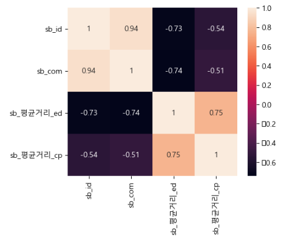

```python
Image('상관계수03.png')
```